# LR.PersonalLoan_ANW

### Thera Bank Personal Loan Campaign

The dataset contains data on 5000 customers. The data include customer demographic information (age, income, etc.), the customer's relationship with the bank (mortgage, securities account, etc.), and the customer response to the last personal loan campaign (Personal Loan). Among these 5000 customers, only 480 (= 9.6%) accepted the personal loan that was offered to them in the earlier campaign.

**Domain:** Banking

**Context:**

This case is about a bank (TheraBank) whose management wants to explore ways of converting its liability customers to personal loan customers (while retaining them as depositors). A campaign that the bank ran last year for liability customers showed a healthy conversion rate of over 9% success. This has encouraged the retail marketing department to devise campaigns with better target marketing to increase the success ratio with a minimal budget.

**Attribute Information:** Customer ID; Age; Professional Experience; CCAVg (Average spending on credit cards); Mortgage; Personal Loan; SecuritiesAccount with the bank; CDA Account with the bank; Online(Internet Banking Facilities); CreditCard issued by the bank; Zip Code; Family size; Income.

**Learning Outcomes:**

- Exploratory Data Analysis
- Preparing the data to train amodel
- Training and making predictions using a classification model
- Model evaluation

**Objective:** The classification goal is to predict the likelihood of a liability customer buying personal loans.

**Steps and tasks:**

- Import the datasets and libraries, check datatype, statistical summary,shape,null values or incorrect imputation - EDA: Analyze data distribution in each attribute and target variable, and share findings:
  - Number of unique in each column?
  - Number of people with zero mortgage?
  - Number of people with zero credit card spending per month?
  - Value counts of all categorical columns.
  - Univariate and Bivariate
  - Get data model ready
- Split the data into training and test set in the ratio of 70:30 respectively
- Use Logistic Regression model to predict whether the customer will take personal loan or not.
- Print all the metrics related for evaluating the model performance
- Check different parameters of Logistic Regression and give your reasoning whether the model performance is affected due to it or not?
- Give Business understanding of your model?

**Project #2 - Logistic Regression - Alex N Waithera**

## Import Libraries

```python
#Import the libraries to use
import warnings
warnings.filterwarnings('ignore')
import numpy as np
import pandas as pd
import matplotlib.pyplot as plt
%matplotlib inline
import seaborn as sns
from sklearn.preprocessing import StandardScaler
from sklearn.preprocessing import Normalizer
from sklearn.model_selection import train_test_split
from sklearn.metrics import confusion_matrix, recall_score, precision_score, f1_score, roc_auc_score,accuracy_score
from sklearn.linear_model import LogisticRegression
from sklearn.metrics import roc_auc_score
from sklearn.metrics import roc_curve
```

## Load and review data

```python
#Load and review data using pandas
df = pd.read_csv("bankpersonalloan.csv")

df.head()
```

|  | ID | Age | Experience | Income | ZIP Code | Family | CCAvg | Education | Mortgage | Personal Loan | Securities Account | CD Account | Online | CreditCard |
| --- | --- | --- | --- | --- | --- | --- | --- | --- | --- | --- | --- | --- | --- | --- |
| 0 | 1 | 25 | 1 | 49 | 91107 | 4 | 1.6 | 1 | 0 | 0 | 1 | 0 | 0 | 0 |
| 1 | 2 | 45 | 19 | 34 | 90089 | 3 | 1.5 | 1 | 0 | 0 | 1 | 0 | 0 | 0 |
| 2 | 3 | 39 | 15 | 11 | 94720 | 1 | 1.0 | 1 | 0 | 0 | 0 | 0 | 0 | 0 |
| 3 | 4 | 35 | 9 | 100 | 94112 | 1 | 2.7 | 2 | 0 | 0 | 0 | 0 | 0 | 0 |
| 4 | 5 | 35 | 8 | 45 | 91330 | 4 | 1.0 | 2 | 0 | 0 | 0 | 0 | 0 | 1 |

```python
# As per the project description, the columns 'Income', 'CCAVg' and 'Mortgage' are to be in thousands ($000) dollars:

df['Income'] *= float(1000)
df['CCAvg'] *= float(1000)
df['Mortgage'] *= float(1000)
```

```python
#Review the first few rows of the dataset
df.head() # as shown below these columns are now in thousands ($000) dollars as indicated.
```

|  | ID | Age | Experience | Income | ZIP Code | Family | CCAvg | Education | Mortgage | Personal Loan | Securities Account | CD Account | Online | CreditCard |
| --- | --- | --- | --- | --- | --- | --- | --- | --- | --- | --- | --- | --- | --- | --- |
| 0 | 1 | 25 | 1 | 49000.0 | 91107 | 4 | 1600.0 | 1 | 0.0 | 0 | 1 | 0 | 0 | 0 |
| 1 | 2 | 45 | 19 | 34000.0 | 90089 | 3 | 1500.0 | 1 | 0.0 | 0 | 1 | 0 | 0 | 0 |
| 2 | 3 | 39 | 15 | 11000.0 | 94720 | 1 | 1000.0 | 1 | 0.0 | 0 | 0 | 0 | 0 | 0 |
| 3 | 4 | 35 | 9 | 100000.0 | 94112 | 1 | 2700.0 | 2 | 0.0 | 0 | 0 | 0 | 0 | 0 |
| 4 | 5 | 35 | 8 | 45000.0 | 91330 | 4 | 1000.0 | 2 | 0.0 | 0 | 0 | 0 | 0 | 1 |

```python
# Display statistical summary of the dataset
df.describe()
```

|  | ID | Age | Experience | Income | ZIP Code | Family | CCAvg | Education | Mortgage | Personal Loan | Securities Account | CD Account | Online | CreditCard |
| --- | --- | --- | --- | --- | --- | --- | --- | --- | --- | --- | --- | --- | --- | --- |
| count | 5000.000000 | 5000.000000 | 5000.000000 | 5000.000000 | 5000.000000 | 5000.000000 | 5000.00000 | 5000.000000 | 5000.000000 | 5000.000000 | 5000.000000 | 5000.00000 | 5000.000000 | 5000.000000 |
| mean | 2500.500000 | 45.338400 | 20.104600 | 73774.200000 | 93152.503000 | 2.396400 | 1937.93800 | 1.881000 | 56498.800000 | 0.096000 | 0.104400 | 0.06040 | 0.596800 | 0.294000 |
| std | 1443.520003 | 11.463166 | 11.467954 | 46033.729321 | 2121.852197 | 1.147663 | 1747.65898 | 0.839869 | 101713.802102 | 0.294621 | 0.305809 | 0.23825 | 0.490589 | 0.455637 |
| min | 1.000000 | 23.000000 | -3.000000 | 8000.000000 | 9307.000000 | 1.000000 | 0.00000 | 1.000000 | 0.000000 | 0.000000 | 0.000000 | 0.00000 | 0.000000 | 0.000000 |
| 25% | 1250.750000 | 35.000000 | 10.000000 | 39000.000000 | 91911.000000 | 1.000000 | 700.00000 | 1.000000 | 0.000000 | 0.000000 | 0.000000 | 0.00000 | 0.000000 | 0.000000 |
| 50% | 2500.500000 | 45.000000 | 20.000000 | 64000.000000 | 93437.000000 | 2.000000 | 1500.00000 | 2.000000 | 0.000000 | 0.000000 | 0.000000 | 0.00000 | 1.000000 | 0.000000 |
| 75% | 3750.250000 | 55.000000 | 30.000000 | 98000.000000 | 94608.000000 | 3.000000 | 2500.00000 | 3.000000 | 101000.000000 | 0.000000 | 0.000000 | 0.00000 | 1.000000 | 1.000000 |
| max | 5000.000000 | 67.000000 | 43.000000 | 224000.000000 | 96651.000000 | 4.000000 | 10000.00000 | 3.000000 | 635000.000000 | 1.000000 | 1.000000 | 1.00000 | 1.000000 | 1.000000 |

Observation:

- The dataset has about 5000 entries with 14 variables consisting of one ID variable which will be dropped later in the analysis.
- Of the 14 variables, four(5) variables i.e. 'Age', 'Experience', 'Income', 'Mortgage' , & 'CCAvg' are numerical while the other eight variables are categorical, that is: 'ZIP Code', 'Family', 'Education', 'Personal Loan', 'Securities Account', 'CD Account', 'Online' , and 'Credit Card'.
- Based on the problem statement, our target variable is 'Personal Loan' which is based on whether a customer accepted the personal loan offered in the last campaign.
- Using the 12 independent variables, excluding the ID variable, a Logistic Regression Model will be build to predict the 'Personal Loan' independent variable. The model will predict whether the customer will take personal loan or not.

```python
# Display information and shape of the dataframe:
df.info()
df.shape
```

```
<class 'pandas.core.frame.DataFrame'>
RangeIndex: 5000 entries, 0 to 4999
Data columns (total 14 columns):
ID                    5000 non-null int64
Age                   5000 non-null int64
Experience            5000 non-null int64
Income                5000 non-null float64
ZIP Code              5000 non-null int64
Family                5000 non-null int64
CCAvg                 5000 non-null float64
Education             5000 non-null int64
Mortgage              5000 non-null float64
Personal Loan         5000 non-null int64
Securities Account    5000 non-null int64
CD Account            5000 non-null int64
Online                5000 non-null int64
CreditCard            5000 non-null int64
dtypes: float64(3), int64(11)
memory usage: 547.0 KB
```

```
(5000, 14)
```

Observation:

- The dataset has 5000 rows and 14 columns.
- The 5000 entries are a combination of int64 and float64 non-null values.

```python
# Check datatype
df.dtypes
```

```
ID                      int64
Age                     int64
Experience              int64
Income                float64
ZIP Code                int64
Family                  int64
CCAvg                 float64
Education               int64
Mortgage              float64
Personal Loan           int64
Securities Account      int64
CD Account              int64
Online                  int64
CreditCard              int64
dtype: object
```

Observation:

- The dataframe is an object that has three (3) variables with float64 datatype while the other 11 variables have an int64 datatype.

**Inspect data for missing values (null values) and incorrect imputation**

```python
# Print non-null number of the movings ratings data
df.count()
#Check for any null values in the dataset
df.isnull().values.any()
```

```
False
```

```python
# count number of missing values in each column
# sum True's
df.isnull().sum()
```

```
ID                    0
Age                   0
Experience            0
Income                0
ZIP Code              0
Family                0
CCAvg                 0
Education             0
Mortgage              0
Personal Loan         0
Securities Account    0
CD Account            0
Online                0
CreditCard            0
dtype: int64
```

Observation:

- This dataset does not have any missing values or null values.
- However, reviewing the statistical summary displayed above, we note that the 'Experience' variable has negative values.
- These negative values in the 'Experience' variable denote an incorrect imputation that needs to be corrected with the mode of the 'Experience' series.

```python
any(df['Experience'] < 0)
```

```
True
```

```python
Expe_mode = df.loc[:,"Experience"].mode()
df.loc[:, 'Experience'].replace([-1, -2, -3], [Expe_mode, Expe_mode, Expe_mode], inplace=True)
```

```python
any(df['Experience'] < 0)
```

```
False
```

Observation:

- The above code checked for any negative values in the 'Experience' variable as observed in the statistical summary and imputed the confirmed negative values with the mode of the 'Experience' Series.
- Rechecking this incorrect imputation confirms that it has been corrected.

**Exploratory Data Analysis (EDA)**

a) **Data distribution in independent variables**

```python
# As mentioned before, we will drop the ID variable because it is not needed in the analysis or building the model.
df2 = df.drop('ID', axis =1 )
df2.head()
```

|  | Age | Experience | Income | ZIP Code | Family | CCAvg | Education | Mortgage | Personal Loan | Securities Account | CD Account | Online | CreditCard |
| --- | --- | --- | --- | --- | --- | --- | --- | --- | --- | --- | --- | --- | --- |
| 0 | 25 | 1 | 49000.0 | 91107 | 4 | 1600.0 | 1 | 0.0 | 0 | 1 | 0 | 0 | 0 |
| 1 | 45 | 19 | 34000.0 | 90089 | 3 | 1500.0 | 1 | 0.0 | 0 | 1 | 0 | 0 | 0 |
| 2 | 39 | 15 | 11000.0 | 94720 | 1 | 1000.0 | 1 | 0.0 | 0 | 0 | 0 | 0 | 0 |
| 3 | 35 | 9 | 100000.0 | 94112 | 1 | 2700.0 | 2 | 0.0 | 0 | 0 | 0 | 0 | 0 |
| 4 | 35 | 8 | 45000.0 | 91330 | 4 | 1000.0 | 2 | 0.0 | 0 | 0 | 0 | 0 | 1 |

```python
df2.describe()
```

|  | Age | Experience | Income | ZIP Code | Family | CCAvg | Education | Mortgage | Personal Loan | Securities Account | CD Account | Online | CreditCard |
| --- | --- | --- | --- | --- | --- | --- | --- | --- | --- | --- | --- | --- | --- |
| count | 5000.000000 | 5000.000000 | 5000.000000 | 5000.000000 | 5000.000000 | 5000.00000 | 5000.000000 | 5000.000000 | 5000.000000 | 5000.000000 | 5000.00000 | 5000.000000 | 5000.000000 |
| mean | 45.338400 | 20.452400 | 73774.200000 | 93152.503000 | 2.396400 | 1937.93800 | 1.881000 | 56498.800000 | 0.096000 | 0.104400 | 0.06040 | 0.596800 | 0.294000 |
| std | 11.463166 | 11.315093 | 46033.729321 | 2121.852197 | 1.147663 | 1747.65898 | 0.839869 | 101713.802102 | 0.294621 | 0.305809 | 0.23825 | 0.490589 | 0.455637 |
| min | 23.000000 | 0.000000 | 8000.000000 | 9307.000000 | 1.000000 | 0.00000 | 1.000000 | 0.000000 | 0.000000 | 0.000000 | 0.00000 | 0.000000 | 0.000000 |
| 25% | 35.000000 | 11.000000 | 39000.000000 | 91911.000000 | 1.000000 | 700.00000 | 1.000000 | 0.000000 | 0.000000 | 0.000000 | 0.00000 | 0.000000 | 0.000000 |
| 50% | 45.000000 | 21.000000 | 64000.000000 | 93437.000000 | 2.000000 | 1500.00000 | 2.000000 | 0.000000 | 0.000000 | 0.000000 | 0.00000 | 1.000000 | 0.000000 |
| 75% | 55.000000 | 30.000000 | 98000.000000 | 94608.000000 | 3.000000 | 2500.00000 | 3.000000 | 101000.000000 | 0.000000 | 0.000000 | 0.00000 | 1.000000 | 1.000000 |
| max | 67.000000 | 43.000000 | 224000.000000 | 96651.000000 | 4.000000 | 10000.00000 | 3.000000 | 635000.000000 | 1.000000 | 1.000000 | 1.00000 | 1.000000 | 1.000000 |

```python
df2.skew()
```

```
Age                   -0.029341
Experience            -0.035548
Income                 0.841339
ZIP Code             -12.500221
Family                 0.155221
CCAvg                  1.598443
Education              0.227093
Mortgage               2.104002
Personal Loan          2.743607
Securities Account     2.588268
CD Account             3.691714
Online                -0.394785
CreditCard             0.904589
dtype: float64
```

Observation:

b) **Data distribution in the target variable**

c) **Number of unique values in each column of the dataframe**

```python
# Check the unique values in each column of the dataframe.
df2.nunique()
```

```
Age                    45
Experience             44
Income                162
ZIP Code              467
Family                  4
CCAvg                 108
Education               3
Mortgage              347
Personal Loan           2
Securities Account      2
CD Account              2
Online                  2
CreditCard              2
dtype: int64
```

Observation:

- From the above analysis we can deduce that:
  - 'Age', Experience', 'Income', 'CCAvg', 'Mortgage' have 45, 44, 162, 108, and 347 unique values respectively.
  - The 'ZIP Code' has 467 unique values.
  - 'Family', 'Education', 'Personal Loan' have four (4) and three(3) unique values respectively.
  - 'Securities Account', 'CD Account', 'Online', & 'CreditCard' all have two (2) unique values respectively.
  - This analysis tell us that 'Age', Experience', 'Income', 'CCAvg',& 'Mortgage' are numerical variables while Family', 'Education', & 'Personal Loan' are categorical variables.
  - 'ZIP Code' is a categorical feature with 467 ZIP Codes.

d) **Number of people with zero mortgage.**

```python
#'Mortgage' & 'CCAvg' independent numerical variables need more analysis as they are more skewed to the right (positively skewed) compared to the other numerical variables:

for i in ['Mortgage', 'CCAvg']:
    count = (df2[i]).value_counts(normalize=False)
    print(count)
```

```
0.0         3462
98000.0       17
119000.0      16
89000.0       16
83000.0       16
91000.0       16
103000.0      16
90000.0       15
102000.0      15
78000.0       15
104000.0      14
94000.0       14
131000.0      14
87000.0       14
118000.0      14
101000.0      14
116000.0      13
144000.0      13
112000.0      13
81000.0       13
106000.0      13
109000.0      13
121000.0      12
185000.0      12
76000.0       12
100000.0      12
120000.0      12
97000.0       12
84000.0       11
153000.0      11
            ...
553000.0       1
505000.0       1
265000.0       1
383000.0       1
612000.0       1
351000.0       1
355000.0       1
278000.0       1
302000.0       1
```

[output cut: 69 more lines]

```
6200.0       2
8500.0       2
4250.0       2
4750.0       2
8300.0       2
3250.0       1
4670.0       1
5330.0       1
8200.0       1
2750.0       1
3330.0       1
8900.0       1
3670.0       1
9300.0       1
Name: CCAvg, Length: 108, dtype: int64
```

Observation:

- There are 3,462 people with zero(0) mortgage.
- There are 106 people with zero (0) credit card spending per month.

e) **Value counts of all categorical columns.**

The categorical variables include the following:

- Family
- ZIP Code
- Personal Loan (Target variable)
- Education
- Securities Account
- CD Account
- Online
- CreditCard

```python
#Value counts of all categorical columns
for i in ['Family', 'ZIP Code', 'Personal Loan', 'Education', 'Securities Account', 'CD Account', 'Online', 'CreditCard']:
    count = (df2[i]).value_counts(normalize=True)
    print(count)
```

```
1    0.2944
2    0.2592
4    0.2444
3    0.2020
Name: Family, dtype: float64
94720    0.0338
94305    0.0254
95616    0.0232
90095    0.0142
93106    0.0114
92037    0.0108
93943    0.0108
91320    0.0106
91711    0.0104
94025    0.0104
```

[output cut: 71 more lines]

Observations:

- The Family & Education variables are evenly distributed compared to all other variables.
- Customer liabilities with regards to Securities Account and CD Account are largely skewed to those without these accounts.
- More than 50% of the customers have online accounts.
- Only 29% of the customers have credit cards.
- About 90% of the customers don't have personal loans with the bank.

f) **Univariate & Bivariate Vizualization.**

i) **Univariate Analysis**

Univariate analysis is an extension of the above data exploration checking for data distribution as explained above:

- Age
- Experience
- Income
- Mortgage
- CCAvg (average spending on credit cards)
- Family
- ZIP Code
- Personal Loan (Target variable)
- Education
- Securities Account
- CD Account
- Online
- CreditCard

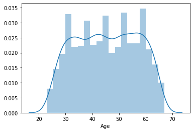

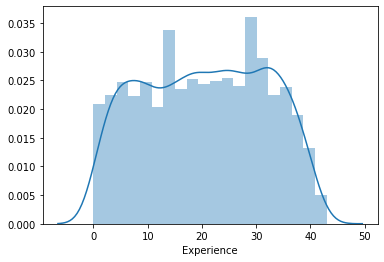

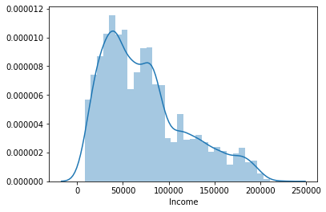

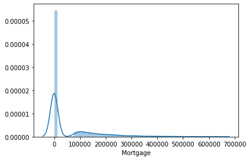

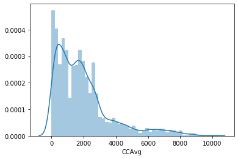

```python
# Analyse data distribution in the continous variables using vizualization:
for i in ['Age','Experience','Income', 'Mortgage', 'CCAvg']:
    sns.distplot(df2[i])
    plt.show()
```

Observation:

- Age & Experience variables show a normal distribution.
- The mortgage & CCVG variables are skewed to the right.
- However, the mortgage data show a data imbalance with about 69% of the customers having zero mortgage or no mortgage. The CCAvg data show slight data imbalance.

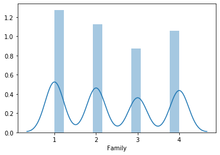

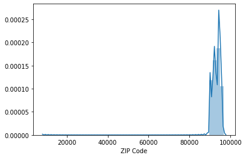

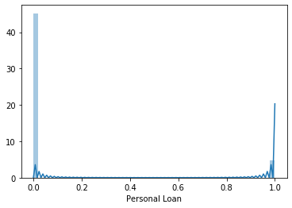

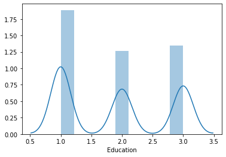

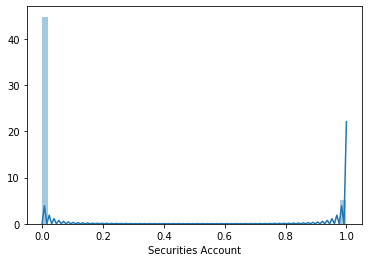

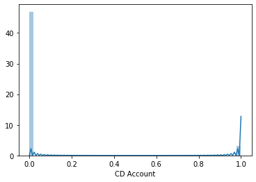

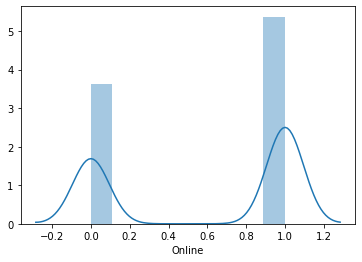

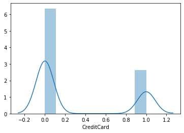

```python
# Analyse data distribution in the categorical variables using vizualization:
for i in ['Family','ZIP Code','Personal Loan', 'Education', 'Securities Account', 'CD Account', 'Online', 'CreditCard']:
    sns.distplot(df2[i])
    plt.show()
```

Observations:

- The categorical variables show bank's customer's liabilities i.e. customers with different financial accounts with the bank and their demographics.
- There are more bank's customers that have a family size of category one (1) compared to category (4).
- There are more customers without credit cards than those that have.
- There are more customers with online accounts than those without.
- Majority of customers don't have personal loans.
- Very few customers have CD and Securities accounts.
- Many customers have undergraduate education compared to those with graduate education.

ii) **Bivariate Analysis**

- In this section, we will do a bivariate analysis using vizualization to compare the target variable with independent variables.

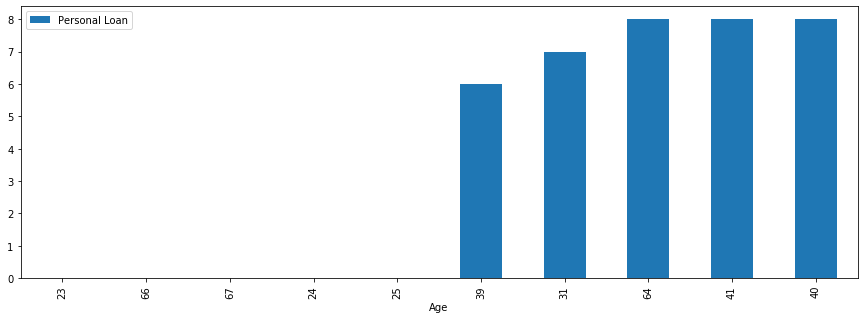

```python
df2.groupby(by=['Age'])['Personal Loan'].sum().reset_index().sort_values(['Personal Loan'],
                    ascending=True).head(10).plot(x='Age',y='Personal Loan',kind='bar', figsize=(15,5))

plt.show()
```

Observation:

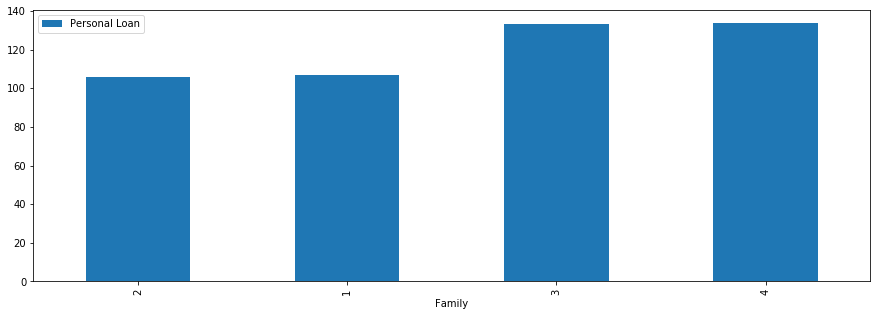

```python
df2.groupby(by=['Family'])['Personal Loan'].sum().reset_index().sort_values(['Personal Loan'],
                    ascending=True).head(10).plot(x='Family',y='Personal Loan',kind='bar', figsize=(15,5))

plt.show()
```

Observation:

- Subscriptions to personal loans seem to increase with increasing family size. Subscriptions of personal loans are are more in families with size four(4) and three(3) compared to family sizes one and two.

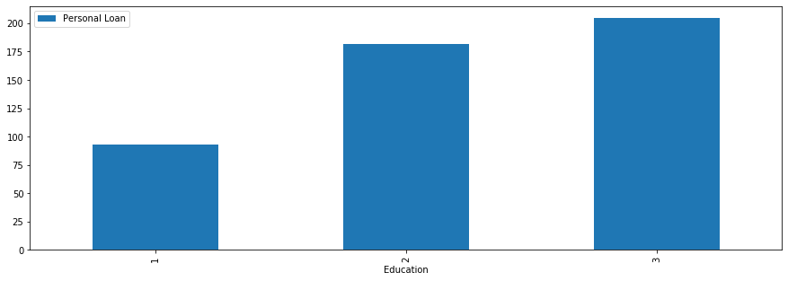

```python
df2.groupby(by=['Education'])['Personal Loan'].sum().reset_index().sort_values(['Personal Loan'],
                    ascending=True).head(10).plot(x='Education',y='Personal Loan',kind='bar', figsize=(15,5))

plt.show()
```

Observation:

- Personal loan subscriptions are high among advanced professionals and graduates compared to customers with undergrand degrees.

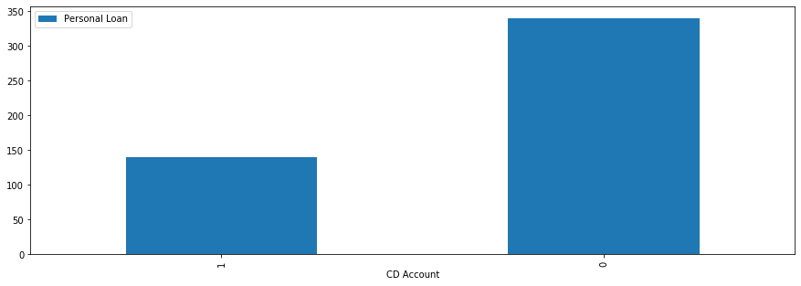

```python
df2.groupby(by=['CD Account'])['Personal Loan'].sum().reset_index().sort_values(['Personal Loan'],
                    ascending=True).head(10).plot(x='CD Account',y='Personal Loan',kind='bar', figsize=(15,5))

plt.show()
```

Observation:

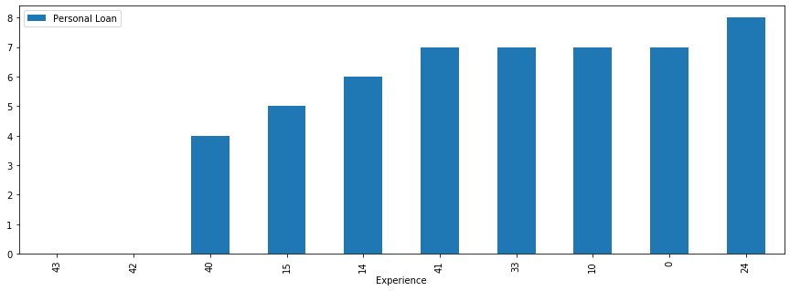

```python
df2.groupby(by=['Experience'])['Personal Loan'].sum().reset_index().sort_values(['Personal Loan'],
                    ascending=True).head(10).plot(x='Experience',y='Personal Loan',kind='bar', figsize=(15,5))

plt.show()
```

Observation:

**Identify Correlation in the Data**

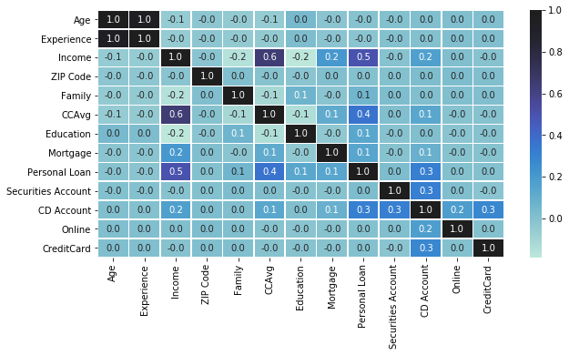

```python
plt.figure(figsize=(10,5))
sns.heatmap(df2.corr(), annot=True, linewidths=.5, fmt= '.1f', center = 1 )  # heatmap
plt.show()
```

```python
df2.corr()
```

|  | Age | Experience | Income | ZIP Code | Family | CCAvg | Education | Mortgage | Personal Loan | Securities Account | CD Account | Online | CreditCard |
| --- | --- | --- | --- | --- | --- | --- | --- | --- | --- | --- | --- | --- | --- |
| Age | 1.000000 | 0.951787 | -0.055269 | -0.029216 | -0.046418 | -0.052012 | 0.041334 | -0.012539 | -0.007726 | -0.000436 | 0.008043 | 0.013702 | 0.007681 |
| Experience | 0.951787 | 1.000000 | -0.049696 | -0.027876 | -0.040770 | -0.047242 | 0.020548 | -0.014691 | -0.017531 | -0.000067 | 0.002699 | 0.012938 | 0.008651 |
| Income | -0.055269 | -0.049696 | 1.000000 | -0.016410 | -0.157501 | 0.645984 | -0.187524 | 0.206806 | 0.502462 | -0.002616 | 0.169738 | 0.014206 | -0.002385 |
| ZIP Code | -0.029216 | -0.027876 | -0.016410 | 1.000000 | 0.011778 | -0.004061 | -0.017377 | 0.007383 | 0.000107 | 0.004704 | 0.019972 | 0.016990 | 0.007691 |
| Family | -0.046418 | -0.040770 | -0.157501 | 0.011778 | 1.000000 | -0.109275 | 0.064929 | -0.020445 | 0.061367 | 0.019994 | 0.014110 | 0.010354 | 0.011588 |
| CCAvg | -0.052012 | -0.047242 | 0.645984 | -0.004061 | -0.109275 | 1.000000 | -0.136124 | 0.109905 | 0.366889 | 0.015086 | 0.136534 | -0.003611 | -0.006689 |
| Education | 0.041334 | 0.020548 | -0.187524 | -0.017377 | 0.064929 | -0.136124 | 1.000000 | -0.033327 | 0.136722 | -0.010812 | 0.013934 | -0.015004 | -0.011014 |
| Mortgage | -0.012539 | -0.014691 | 0.206806 | 0.007383 | -0.020445 | 0.109905 | -0.033327 | 1.000000 | 0.142095 | -0.005411 | 0.089311 | -0.005995 | -0.007231 |
| Personal Loan | -0.007726 | -0.017531 | 0.502462 | 0.000107 | 0.061367 | 0.366889 | 0.136722 | 0.142095 | 1.000000 | 0.021954 | 0.316355 | 0.006278 | 0.002802 |
| Securities Account | -0.000436 | -0.000067 | -0.002616 | 0.004704 | 0.019994 | 0.015086 | -0.010812 | -0.005411 | 0.021954 | 1.000000 | 0.317034 | 0.012627 | -0.015028 |
| CD Account | 0.008043 | 0.002699 | 0.169738 | 0.019972 | 0.014110 | 0.136534 | 0.013934 | 0.089311 | 0.316355 | 0.317034 | 1.000000 | 0.175880 | 0.278644 |
| Online | 0.013702 | 0.012938 | 0.014206 | 0.016990 | 0.010354 | -0.003611 | -0.015004 | -0.005995 | 0.006278 | 0.012627 | 0.175880 | 1.000000 | 0.004210 |
| CreditCard | 0.007681 | 0.008651 | -0.002385 | 0.007691 | 0.011588 | -0.006689 | -0.011014 | -0.007231 | 0.002802 | -0.015028 | 0.278644 | 0.004210 | 1.000000 |

Observation:

- A lot of the independent variables seem not to have a correlation with the target variable. The only independent variables that seem to have a moderate or weak correlation with the target variable are 'Income', 'CCAvg' and 'CD Account'.

**Getting the model ready through one-hot-encoding, standardization and normalization**

```python
## Define X and Y variables
X = df2.drop(['Personal Loan'], axis=1)
Y = df2[['Personal Loan']]
```

```python
#Convert categorical vriables to dummy variables
X = pd.get_dummies(X, drop_first=True)
```

```python
# Standardize data (0 mean, 1 stdev)
X = df2.drop(['Personal Loan'], axis=1)
Y = df2[['Personal Loan']]
scaler = StandardScaler().fit(X)
X = scaler.transform(X)
```

```python
# Normalize data (length of 1)
scaler = Normalizer().fit(X)
X = scaler.transform(X)
```

**Splitting the data into training and test set in the ratio of 70:30 respectively**

```python
##Split into training and test set
X_train, X_test, y_train, y_test = train_test_split(X, Y, test_size=0.30,random_state=7)
```

```python
logreg = LogisticRegression(random_state=7)
logreg.fit(X_train, y_train)
```

```
LogisticRegression(random_state=7)
```

```python
# Predict the target variable on test data
y_predict = logreg.predict(X_test)
```

**Model Building using Logistic Regression from Scikit-Learn**

```python
#function to get confusion matrix in a proper format
def draw_cm( actual, predicted ):
    cm = confusion_matrix( actual, predicted)
    sns.heatmap(cm, annot=True,  fmt='.2f', xticklabels = [0,1] , yticklabels = [0,1] )
    plt.ylabel('Observed')
    plt.xlabel('Predicted')
    plt.show()
```

```
Trainig accuracy 0.9565714285714285

Testing accuracy 0.9586666666666667

Confusion Matrix
```

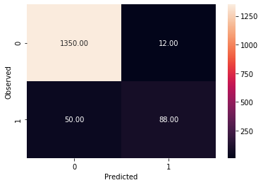

```
None

Recall: 0.6376811594202898

Precision: 0.88

F1 Score: 0.7394957983193275

Roc Auc Score: 0.8144352933665326
```

```python
print("Trainig accuracy",logreg.score(X_train,y_train))
print()
print("Testing accuracy",logreg.score(X_test, y_test))
print()
print('Confusion Matrix')
print(draw_cm(y_test,y_predict))
print()
print("Recall:",recall_score(y_test,y_predict))
print()
print("Precision:",precision_score(y_test,y_predict))
print()
print("F1 Score:",f1_score(y_test,y_predict))
print()
print("Roc Auc Score:",roc_auc_score(y_test,y_predict))
```

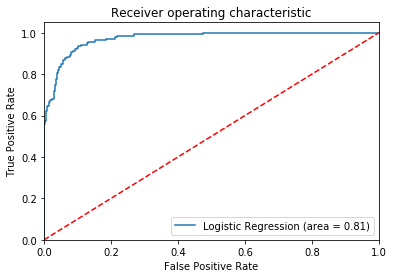

```python
#AUC ROC curve
logit_roc_auc = roc_auc_score(y_test, logreg.predict(X_test))
fpr, tpr, thresholds = roc_curve(y_test, logreg.predict_proba(X_test)[:,1])
plt.figure()
plt.plot(fpr, tpr, label='Logistic Regression (area = %0.2f)' % logit_roc_auc)
plt.plot([0, 1], [0, 1],'r--')
plt.xlim([0.0, 1.0])
plt.ylim([0.0, 1.05])
plt.xlabel('False Positive Rate')
plt.ylabel('True Positive Rate')
plt.title('Receiver operating characteristic')
plt.legend(loc="lower right")
plt.savefig('Log_ROC')
plt.show()
```

**Model Evaluation**

**Checking different parameters of LR to give reasoning whether the model performance is affected to it or not**

```python
# Checking Parameters of logistic regression
logreg.get_params()
```

```
{'C': 1.0,
 'class_weight': None,
 'dual': False,
 'fit_intercept': True,
 'intercept_scaling': 1,
 'l1_ratio': None,
 'max_iter': 100,
 'multi_class': 'auto',
 'n_jobs': None,
 'penalty': 'l2',
 'random_state': 7,
 'solver': 'lbfgs',
 'tol': 0.0001,
 'verbose': 0,
 'warm_start': False}
```

```python
# Running a loop to check different values of 'solver'
train_score=[]
test_score=[]
solver = ['newton-cg','lbfgs','liblinear','sag','saga']
for i in solver:
    model = LogisticRegression(random_state=50,penalty='l2', C = 0.25,solver=i)  # changing values of solver
    model.fit(X_train, y_train)
    y_predict = model.predict(X_test)
    train_score.append(round(model.score(X_train, y_train),3))
    test_score.append(round(model.score(X_test, y_test),3))

print(solver)
print()
print(train_score)
print()
print(test_score)
```

```
['newton-cg', 'lbfgs', 'liblinear', 'sag', 'saga']

[0.948, 0.948, 0.948, 0.948, 0.948]

[0.956, 0.956, 0.956, 0.956, 0.956]
```

```python
train_score=[]
test_score=[]
solver = ['liblinear','saga']
for i in solver:
    model = LogisticRegression(random_state=42,penalty='l1', C = 0.25,solver=i)  #changed penalty to 'l1'
    model.fit(X_train, y_train)
    y_predict = model.predict(X_test)
    train_score.append(round(model.score(X_train, y_train),3))
    test_score.append(round(model.score(X_test, y_test),3))

print(solver)
print()
print(train_score)
print()
print(test_score)
```

```
['liblinear', 'saga']

[0.956, 0.956]

[0.959, 0.959]
```

```python
model = LogisticRegression(random_state=42,penalty='l1',solver='saga',class_weight='balanced') # changing class weight to balanced

model.fit(X_train, y_train)

y_predict = model.predict(X_test)

print("Trainig accuracy",model.score(X_train,y_train))
print()
print("Testing accuracy",model.score(X_test, y_test))
```

```
Trainig accuracy 0.8734285714285714

Testing accuracy 0.874
```

```python
# Running a loop to check different values of 'C'

train_score=[]
test_score=[]
C = [0.01,0.1,0.25,0.5,0.75,1]
for i in C:
    model = LogisticRegression(random_state=42,penalty='l1', solver='saga',class_weight='balanced', C=i)  # changing values of C
    model.fit(X_train, y_train)
    y_predict = model.predict(X_test)
    train_score.append(round(model.score(X_train,y_train),3))
    test_score.append(round(model.score(X_test, y_test),3))

print(C)
print()
print(train_score)
print()
print(test_score)
```

```
[0.01, 0.1, 0.25, 0.5, 0.75, 1]

[0.823, 0.879, 0.869, 0.885, 0.869, 0.873]

[0.836, 0.873, 0.876, 0.877, 0.866, 0.874]
```

```
Training accuracy 0.8685714285714285

Testing accuracy 0.876

Confusion Matrix
```

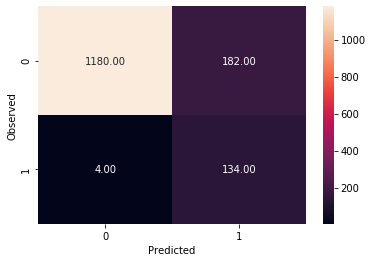

```
None

Recall: 0.9710144927536232

Precision: 0.4240506329113924

F1 Score: 0.5903083700440529

Roc Auc Score: 0.9186937368320244
```

```python
#Adjusted Logistic Regression model using using different Logistic Regression Parameters:
model = LogisticRegression(random_state=42,penalty='l1', solver='saga', class_weight='balanced',C=0.25)
model.fit(X_train, y_train)
y_predict = model.predict(X_test)
print("Training accuracy",model.score(X_train,y_train))
print()
print("Testing accuracy",model.score(X_test, y_test))
print()
print('Confusion Matrix')
print(draw_cm(y_test,y_predict))
print()
print("Recall:",recall_score(y_test,y_predict))
print()
print("Precision:",precision_score(y_test,y_predict))
print()
print("F1 Score:",f1_score(y_test,y_predict))
print()
print("Roc Auc Score:",roc_auc_score(y_test,y_predict))
```

Observations:

**Business Understanding of the Model**